# Practical Machine Learning

## Coursera Practical Machine Learning Project

### Background

Using devices such as Jawbone Up, Nike FuelBand, and Fitbit it is now possible to collect a large amount of data about personal activity relatively inexpensively. These type of devices are part of the quantified self movement - a group of enthusiasts who take measurements about themselves regularly to improve their health, to find patterns in their behavior, or because they are tech geeks. One thing that people regularly do is quantify how much of a particular activity they do, but they rarely quantify how well they do it. In this project, the goal will be to use data from accelerometers on the belt, forearm, arm, and dumbell of 6 participants. They were asked to perform barbell lifts correctly and incorrectly in 5 different ways. More information is available from the website here: http://groupware.les.inf.puc-rio.br/har (see the section on the Weight Lifting Exercise Dataset).

### Data

The data for this project come from this source:http://groupware.les.inf.puc-rio.br/har

### Modeling

#### 1. Cleaning Data

- Load libraries

The pml-training.csv data is used to devise training and testing sets for fitting of the prediction model. The pml-test.csv data is used to submit 20 test cases based on the fitted model.

```r
library(mlbench)
library(caret)
```

```r
library(ggplot2)
library(randomForest)
set.seed(5)
```

- Load data

```r
download.file("http://d396qusza40orc.cloudfront.net/predmachlearn/pml-training.csv", "pml-training.csv")
download.file("http://d396qusza40orc.cloudfront.net/predmachlearn/pml-testing.csv", "pml-testing.csv")
```

- Clean the data

All blank(“”),“#DIV/0” and “NA” values are converted to ‘NA’.

```r
training<-read.csv('pml-training.csv', na.strings=c("NA","#DIV/0!", ""),head=TRUE)
test<-read.csv('pml-testing.csv', na.strings=c("NA","#DIV/0!", ""),head=TRUE)
```

Get the sumamry and dimension of the training data.

```r
dim(training)
summary(training)
```

[output not shown]

It is found from summary result that it is necessary to remove columns with equal and more than 19216 NAs which will not contribute to the prediction model. This will result in only 60 columns in the dataset.

```r
training<-training[,colSums(is.na(training))<19216]
training<-training[sapply(training,function(training) !any(is.na(training)))]
dim(training)
```

```
## [1] 19622    60
```

Since the first 7 columns are irrelevant to the model prediction, they are removed from the data. In addition, nsv results indicate there is no near zero variance predictor.

```r
training<-training[,8:60]
nsv<-nearZeroVar(training,saveMetrics=TRUE)
nsv
```

```
##                      freqRatio percentUnique zeroVar   nzv
## roll_belt             1.101904     6.7781062   FALSE FALSE
## pitch_belt            1.036082     9.3772296   FALSE FALSE
## yaw_belt              1.058480     9.9734991   FALSE FALSE
## total_accel_belt      1.063160     0.1477933   FALSE FALSE
## gyros_belt_x          1.058651     0.7134849   FALSE FALSE
## gyros_belt_y          1.144000     0.3516461   FALSE FALSE
## gyros_belt_z          1.066214     0.8612782   FALSE FALSE
## accel_belt_x          1.055412     0.8357966   FALSE FALSE
## accel_belt_y          1.113725     0.7287738   FALSE FALSE
## accel_belt_z          1.078767     1.5237998   FALSE FALSE
## magnet_belt_x         1.090141     1.6664968   FALSE FALSE
## magnet_belt_y         1.099688     1.5187035   FALSE FALSE
## magnet_belt_z         1.006369     2.3290184   FALSE FALSE
## roll_arm             52.338462    13.5256345   FALSE FALSE
## pitch_arm            87.256410    15.7323412   FALSE FALSE
## yaw_arm              33.029126    14.6570176   FALSE FALSE
## total_accel_arm       1.024526     0.3363572   FALSE FALSE
## gyros_arm_x           1.015504     3.2769341   FALSE FALSE
## gyros_arm_y           1.454369     1.9162165   FALSE FALSE
## gyros_arm_z           1.110687     1.2638875   FALSE FALSE
## accel_arm_x           1.017341     3.9598410   FALSE FALSE
## accel_arm_y           1.140187     2.7367241   FALSE FALSE
## accel_arm_z           1.128000     4.0362858   FALSE FALSE
## magnet_arm_x          1.000000     6.8239731   FALSE FALSE
## magnet_arm_y          1.056818     4.4439914   FALSE FALSE
## magnet_arm_z          1.036364     6.4468454   FALSE FALSE
## roll_dumbbell         1.022388    84.2065029   FALSE FALSE
## pitch_dumbbell        2.277372    81.7449801   FALSE FALSE
## yaw_dumbbell          1.132231    83.4828254   FALSE FALSE
## total_accel_dumbbell  1.072634     0.2191418   FALSE FALSE
## gyros_dumbbell_x      1.003268     1.2282132   FALSE FALSE
## gyros_dumbbell_y      1.264957     1.4167771   FALSE FALSE
## gyros_dumbbell_z      1.060100     1.0498420   FALSE FALSE
## accel_dumbbell_x      1.018018     2.1659362   FALSE FALSE
## accel_dumbbell_y      1.053061     2.3748853   FALSE FALSE
## accel_dumbbell_z      1.133333     2.0894914   FALSE FALSE
## magnet_dumbbell_x     1.098266     5.7486495   FALSE FALSE
## magnet_dumbbell_y     1.197740     4.3012945   FALSE FALSE
## magnet_dumbbell_z     1.020833     3.4451126   FALSE FALSE
## roll_forearm         11.589286    11.0895933   FALSE FALSE
## pitch_forearm        65.983051    14.8557741   FALSE FALSE
## yaw_forearm          15.322835    10.1467740   FALSE FALSE
## total_accel_forearm   1.128928     0.3567424   FALSE FALSE
## gyros_forearm_x       1.059273     1.5187035   FALSE FALSE
## gyros_forearm_y       1.036554     3.7763735   FALSE FALSE
## gyros_forearm_z       1.122917     1.5645704   FALSE FALSE
## accel_forearm_x       1.126437     4.0464784   FALSE FALSE
## accel_forearm_y       1.059406     5.1116094   FALSE FALSE
## accel_forearm_z       1.006250     2.9558659   FALSE FALSE
## magnet_forearm_x      1.012346     7.7667924   FALSE FALSE
## magnet_forearm_y      1.246914     9.5403119   FALSE FALSE
## magnet_forearm_z      1.000000     8.5771073   FALSE FALSE
## classe                1.469581     0.0254816   FALSE FALSE
```

- Remove highly correlated variables (threshold=0.75)

```r
classe<-training[,"classe"]
correlationMatrix<-cor(training[,1:52])
diag(correlationMatrix)<-0
correlationMatrix[upper.tri(correlationMatrix)]<-0
training<-training[,!apply(correlationMatrix,2,function(x) any(x>0.75))]
training$classe<-classe
dim(training)
```

```
## [1] 19622    37
```

#### 2. Patitioning Data

The data is partitioned by the classe variable. 75% of the data will be used to train the model and the remaining for cross validation.

```r
trainIndex<-createDataPartition(training$classe,p=0.75,list=FALSE,times=1)
harTrain<-training[trainIndex,]
harValidation<-training[-trainIndex,]
dim(harTrain)
```

```
## [1] 14718    37
```

#### 3. Determining number of predictors

```r
control<-rfeControl(functions=rfFuncs,method="cv",number=10)
results <- rfe(training[,1:36], training[,37], sizes=c(1:36), rfeControl=control)
print(results)
plot(results,type=c("g","o"))
```

[output not shown]

#### 4. Modeling

Random Forest is chosen because of the following attributes.

- accuracy
- handle lots of irrelevant features
- Moderate prediction speed
- automatically learn feature interaction

Random Forest with tuning parameter ‘mtry’ at a value of 9 is used to develop the prediction model. It seems in sample error rate will be higher than out of sample error rate with a random forest model with only 9 variables tried at each split.

```r
mtryGrid<-expand.grid(mtry=9)
rfTune<-train(classe~.,method="rf",data=harTrain,trControl=trainControl(verboseIter=FALSE,method="oob"),tuneGrid=mtryGrid)
print(rfTune$finalModel)
```

```
##
## Call:
##  randomForest(x = x, y = y, mtry = param$mtry)
##                Type of random forest: classification
##                      Number of trees: 500
## No. of variables tried at each split: 9
##
##         OOB estimate of  error rate: 0.74%
## Confusion matrix:
##      A    B    C    D    E class.error
## A 4177    6    1    0    1 0.001911589
## B   17 2820   11    0    0 0.009831461
## C    0   17 2545    5    0 0.008570316
## D    0    1   36 2372    3 0.016583748
## E    0    2    2    7 2695 0.004065041
```

```r
rfTune
```

```
## Random Forest
##
## 14718 samples
##    36 predictor
##     5 classes: 'A', 'B', 'C', 'D', 'E'
##
## No pre-processing
## Resampling results
##
##   Accuracy   Kappa
##   0.9924582  0.9904599
##
## Tuning parameter 'mtry' was held constant at a value of 9
##
```

Importance of the model variables is shown in the below plot.

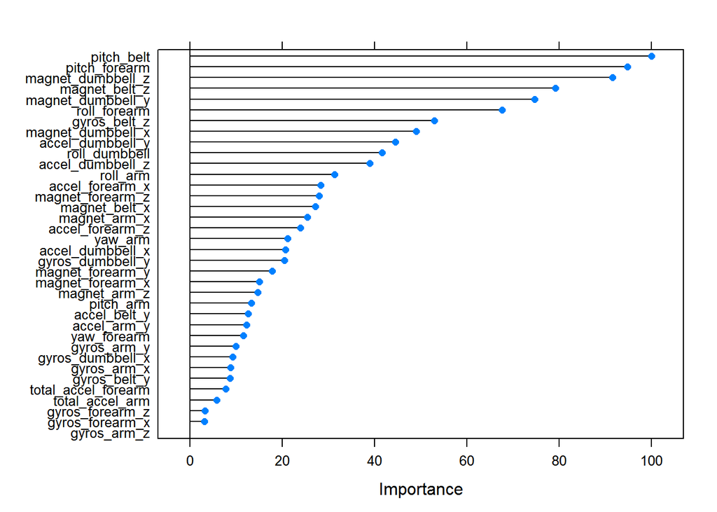

```r
plot(varImp(rfTune))
```

Box plot for the top 3 important variables.

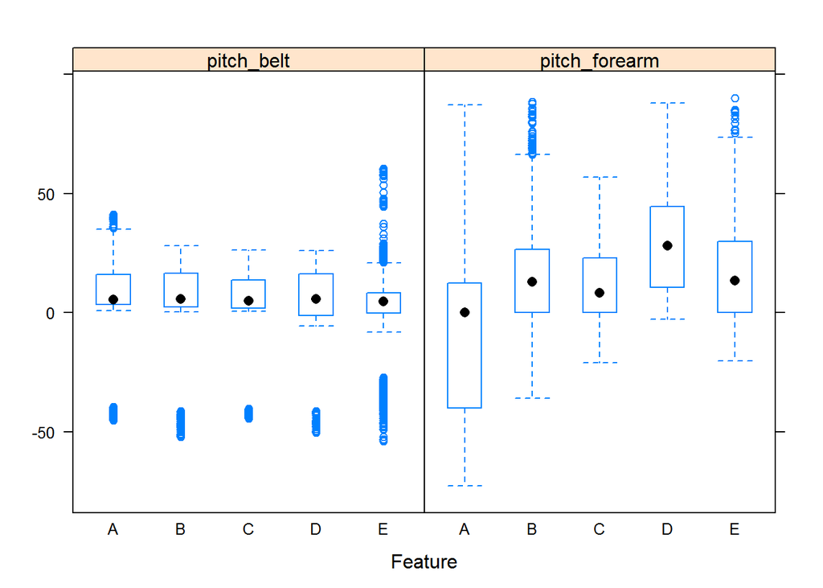

```r
featurePlot(harTrain[,c("pitch_belt","pitch_forearm")],y=harTrain$classe,plot="box")
```

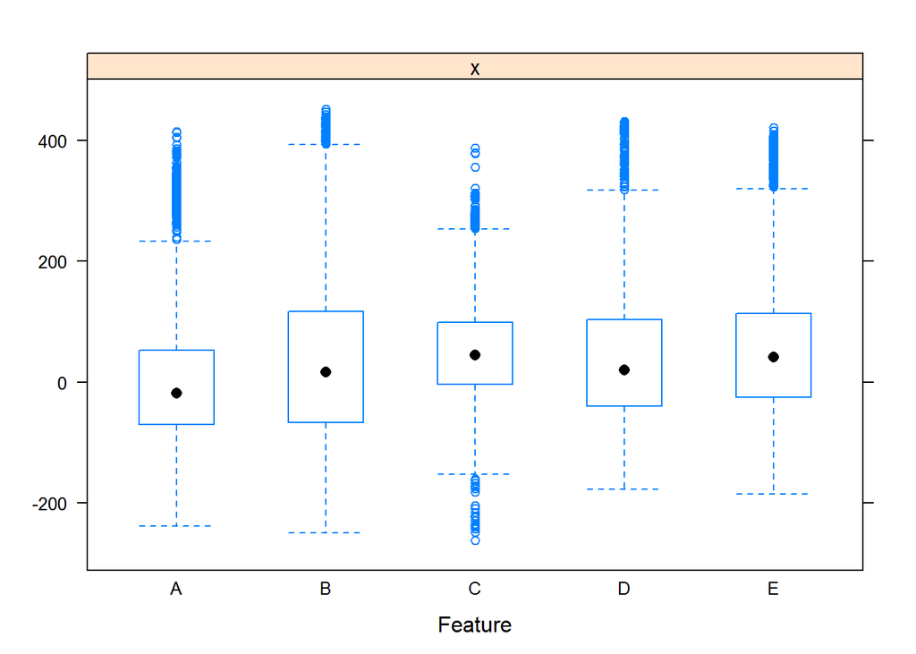

```r
featurePlot(harTrain$magnet_dumbbell_z,y=harTrain$classe,plot="box")
```

It is obvious that even the top 3 most important predictors are not good enough to classify the dataset.

#### 5. Cross validation

```r
pred1<-predict(rfTune,newdata=harValidation)
confMatrix<-confusionMatrix(pred1,harValidation$classe)
confMatrix
```

```
## Confusion Matrix and Statistics
##
##           Reference
## Prediction    A    B    C    D    E
##          A 1394    2    0    0    0
##          B    0  942    8    0    0
##          C    0    4  847    8    0
##          D    0    1    0  796    2
##          E    1    0    0    0  899
##
## Overall Statistics
##
##                Accuracy : 0.9947
##                  95% CI : (0.9922, 0.9965)
##     No Information Rate : 0.2845
##     P-Value [Acc > NIR] : < 2.2e-16
##
##                   Kappa : 0.9933
##  Mcnemar's Test P-Value : NA
##
## Statistics by Class:
##
##                      Class: A Class: B Class: C Class: D Class: E
## Sensitivity            0.9993   0.9926   0.9906   0.9900   0.9978
## Specificity            0.9994   0.9980   0.9970   0.9993   0.9998
## Pos Pred Value         0.9986   0.9916   0.9860   0.9962   0.9989
## Neg Pred Value         0.9997   0.9982   0.9980   0.9981   0.9995
## Prevalence             0.2845   0.1935   0.1743   0.1639   0.1837
## Detection Rate         0.2843   0.1921   0.1727   0.1623   0.1833
## Detection Prevalence   0.2847   0.1937   0.1752   0.1629   0.1835
## Balanced Accuracy      0.9994   0.9953   0.9938   0.9947   0.9988
```

The in sample error rate from the training set is 0.74% and the out of sample error rate from the validation set is 0.53%. Since the out of sample error rate is less than the in sample error rate, it indicates this predition model is not overfitting and it is generally accurate for independent dataset.

#### 6. 20 test cases

```r
colnames<-names(harTrain)
test<-test[,colnames(test)%in%colnames]
test1<-predict(rfTune,newdata=test)
test1<-as.character(test1)

pml_write_files = function(x){
  n = length(x)
  for(i in 1:n){
    filename = paste0("problem_id_",i,".txt")
    write.table(x[i],file=filename,quote=FALSE,row.names=FALSE,col.names=FALSE)
  }
}
pml_write_files(test1)
```